[figure not shown]

# Hands-on introduction to Qiskit

## University of Minho

### [Afonso Rodrigues](https://afonsofr.github.io) and [Ana Neri](https://ana.nery.name/wp/)

### The "big picture"

[figure not shown]

# Contents

- Recall the theory
- First Quantum Circuit
- Simulating circuits with Qiskit Aer
- Running circuits using the IBMQ provider
- Deutsch-Josza Algorithm
- Ignis

## Recall the theory

A single qubit quantum state

$$|\psi\rangle = \alpha|0\rangle + \beta |1\rangle$$

As a vector this is $$ |\psi\rangle = \begin{pmatrix} \alpha \\ \beta \end{pmatrix} \quad \rightarrow \quad |0\rangle = \binom{1}{0} \; ;\; |1\rangle = \binom{0}{1}\,; $$

The normalization rule $|\alpha|^2+ |\beta|^2 = 1$ allows for an alternate representation:

$$|\psi\rangle = \cos \left( \frac{\theta}{2} \right)|0\rangle + \sin\left( \frac{\theta}{2}\right) e^{i\phi}|1\rangle$$

### Bloch sphere

[figure not shown]

$$|\psi\rangle = \cos \left( \frac{\theta}{2} \right)|0\rangle + \sin\left( \frac{\theta}{2}\right) e^{i\phi}|1\rangle$$

Quantum gates/operations may be represented as matrices.

The action of the quantum gate is expressed by the product of its matrix with the vector representing the quantum state.

$$|\psi'\rangle = U|\psi\rangle$$

The most general form of a single qubit unitary gate

$$ U = \begin{pmatrix} \cos(\theta/2) & -e^{i\lambda}\sin(\theta/2) \\ e^{i\phi}\sin(\theta/2) & e^{i\lambda+i\phi}\cos(\theta/2) \end{pmatrix}. $$

An $n$-qubit quantum gate is represented by a $2^n \times 2^n$ matrix.

## Let's start building a circuit

```python
# Ignore warnings for the purpose of this demonstration
import warnings
warnings.filterwarnings('ignore')

# Useful additional packages
import matplotlib.pyplot as plt
%matplotlib inline
import numpy as np
from math import pi

# Relevant QISKit modules
from qiskit import QuantumCircuit, ClassicalRegister, QuantumRegister
```

```python
# Auxiliary functions for circuit execution
from qiskit import Aer, BasicAer, execute
from qiskit.tools.visualization import plot_histogram, circuit_drawer

def show_results(D):
    plt.bar(range(len(D)), list(D.values()), align='center')
    plt.xticks(range(len(D)), list(D.keys()))
    plt.show()


# Execute circuit, display a histogram of the results
def execute_locally(qc, draw_circuit=False):
    # Compile and run the Quantum circuit on a simulator backend
    backend_sim = Aer.get_backend('qasm_simulator')
    job_sim = execute(qc, backend_sim, shots=1000)
    result_sim = job_sim.result()
    result_counts = result_sim.get_counts(qc)

    # Print the results
    print("Simulation: \n\n", result_counts)

    if draw_circuit: # draw the circuit
        qc.draw()
    else: # or show the results
        show_results(result_counts)
```

```python
# Create registers
qr0 = QuantumRegister(2)

# You need a classical register if you want to do measurements!
cr0 = ClassicalRegister(2)

# Create quantum circuit
qc = QuantumCircuit(qr0, cr0)

qc.draw()
```

```
q0_0: |0>

q0_1: |0>

 c0_0: 0

 c0_1: 0
```

#### Circuits are the primary unit of computation in Terra!

Circuits contain:

- name - for referencing the circuit later
- data - list of gates in the circuit
- registers - quantum and classical registers

They do **not** contain information about possible backends.

# Gates

Although the basic gate set of IBM Q devices is $$\{id, u1, u2, u3, cx\}$$

Where $$ U_3(\theta,\phi,\lambda) = \begin{pmatrix} \cos(\theta/2) & -e^{i\lambda}\sin(\theta/2) \\ e^{i\phi}\sin(\theta/2) & e^{i\lambda+i\phi}\cos(\theta/2) \end{pmatrix}. $$

QISKit supports many gates. (Check the [Summary of quantum operations](https://github.com/Qiskit/qiskit-tutorials/blob/master/qiskit/terra/summary_of_quantum_operations.ipynb) in the tutorials of Terra)

#### Example: Gate $X$ (bit-flip gate)

The X-gate is also known as NOT gate or “bit-flip”, since it changes a state $| 0 \rangle $ to $| 1 \rangle $ and vice versa. This is quantum analogue to a classical NOT gate.

On the Bloch sphere representation, this operation corresponds to a rotation of the state around the X-axis by $\pi$ radians.

[figure not shown]

#### Example: $Z$ (phase-flip gate)

The phase flip gate $Z$ is defined as:

$$ Z = \begin{pmatrix} 1 & 0\\ 0 & -1 \end{pmatrix} $$

It leaves the basis state $|0 \rangle $ unchanged, while mapping $| 1 \rangle$ to $- | 1 \rangle $. In the Bloch sphere representation, and similarly to the $X$ gate, it rotates the state around the $Z$ axis by $\pi$ radians.

#### Example: Hadamard gate

The Hadamard gate may be used to create superposition. It maps the basis state $| 0 \rangle$ to $| + \rangle =\frac{| 0 \rangle + | 1 \rangle }{\sqrt{2}}$, and $| 1 \rangle $ to $ | - \rangle =\frac{ |0 \rangle - |1 \rangle }{\sqrt{2}}$.

[figure not shown]

The Hadamard gate, along with the X, Y and Z gates, is self-inverse: $H.H = I$.

## Computational and superposition basis

Any set of orthogonal states spanning all dimensions of the Hilbert space of the quantum state can be used as a basis. The Hadamard gate may be used to easily change between the computational ($| 0 \rangle$ and $|1 \rangle$) and the superpositon basis, where:

- $| + \rangle = \frac{1}{\sqrt{2}} ( | 0 \rangle + | 1 \rangle )$
- $| - \rangle = \frac{1}{\sqrt{2}} ( | 0 \rangle - | 1 \rangle )$

[figure not shown]

The above diagram is a useful shorthand for quantum states conversion using quantum gates, and it also depicts the consequences of reversible computation. Literally, you can have a qubit in any of the four states $|0\rangle$, $|1\rangle$, $|-\rangle$, $|+\rangle$ and obtain any other from it by performing simple one qubit gates.

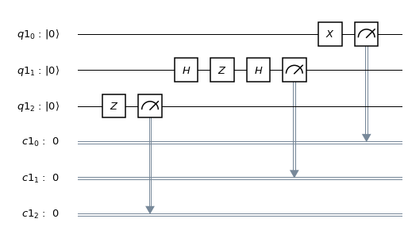

```python
qr = QuantumRegister(3)
cr = ClassicalRegister(3)
qc_basis = QuantumCircuit(qr, cr)
# An X gate in the computational basis
qc_basis.x(qr[0])
# Is equivalent to a Z gate in the superposition basis
qc_basis.h(qr[1])
qc_basis.z(qr[1])
qc_basis.h(qr[1])
# What happens when we apply the Z gate without changing basis?
qc_basis.z(qr[2])
# Measure qubits into classical register
qc_basis.measure(qr,cr)
# Draw the quantum circuits
qc_basis.draw(output='mpl')
```

```
Simulation:

 {'011': 1000}
```

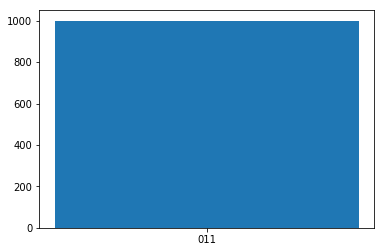

```python
execute_locally(qc_basis)
```

## CNOT and other multi-qubit operations

No set of quantum gates containing only single qubit operations can ever be universal (i.e. form a basis to perform any quantum operation on a multi-qubit quantum system).

The CNOT gate, also known as controlled-X, is the fundamental two-qubit gate. Together with a generalized single-qubit unitary gate, we are able to decompose **any** multi-qubit operation. The CNOT gate takes one qubit as control, and one qubit as target.

- if the control qubit is in the state $| 0 \rangle$, the target qubit is left alone;
- if the control qubit is in the state $| 1 \rangle$, the X gate is applied to the target qubit.

[figure not shown]

This gate allows us to unlock a powerful property of quantum particles: **entanglement**. Without it, quantum computers would lose most of their potential advantage over the classical computing paradigm.

In quantum circuits, CNOT gates are used to entangle pairs of qubits.

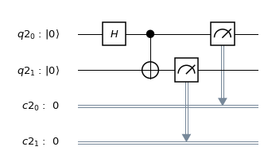

```python
qr = QuantumRegister(2)
cr = ClassicalRegister(2)

qc_multi_qubit = QuantumCircuit(qr, cr)

qc_multi_qubit.h(qr[0])
qc_multi_qubit.cx(qr[0],qr[1])

qc_multi_qubit.measure(qr,cr)

qc_multi_qubit.draw(output='mpl')
```

[figure not shown]

```
Simulation:

 {'00': 508, '11': 492}
```

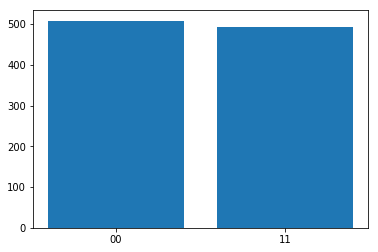

```python
execute_locally(qc_multi_qubit)
```

Other commonly mentioned multi-qubit gates (which can be decomposed into CNOT's):

- The SWAP gate, which exchanges the state of two qubits;
  - `circuit.swap(q[0],q[1])`
- The Tofolli gate, also known as CCNOT.
  - `circuit.ccx(q[0],q[1],q[2])`

# Simulating circuits with Qiskit Aer

In version 0.7 **Aer** was rename to **BasicAer** .

**Aer** will be used to fancier and larger packages.

#### Aer vs BasicAer

- BasicAer: Terra's built-in suite of pure-python simulators
- Aer: Qiskit's suite of high-performance simulators (faster and with noise sophisticated models - aer.noise)

```python
from qiskit import BasicAer, execute
```

```python
BasicAer.backends()
```

```
[<QasmSimulatorPy('qasm_simulator') from BasicAer()>,
 <StatevectorSimulatorPy('statevector_simulator') from BasicAer()>,
 <UnitarySimulatorPy('unitary_simulator') from BasicAer()>]
```

#### Simulators

- statevector_simulator : This is the qasm_simulator with a snapshot at the end

  Returns result object containing a dictionary of basis states with complex amplitudes for each
- unitary_simulator : Returns a matrix of your circuit!
- ibmq_qasm_simulator : a public simulator on an HPC machine run by IBM (Note, this is under the IBMQ provider)

To run the circuit you need to add measurement gates!

**Note**: it is always a good ideia to add barrier before the measurement gates!

```python
qc.measure(qr0, cr0)
qc.draw()
```

```
            ┌─┐
q0_0: |0>───┤M├
         ┌─┐└╥┘
q0_1: |0>┤M├─╫─
         └╥┘ ║
 c0_0: 0 ═╬══╩═
          ║
 c0_1: 0 ═╩════
```

### Statevector_simulator

```python
qc_superposition = QuantumCircuit(qr,cr)
qc_superposition.h(qr[0])
qc_superposition.measure(qr[0],cr[0])
qc_superposition.draw()
```

```
         ┌───┐┌─┐
q2_0: |0>┤ H ├┤M├
         └───┘└╥┘
q2_1: |0>──────╫─
               ║
 c2_0: 0 ══════╩═

 c2_1: 0 ════════
```

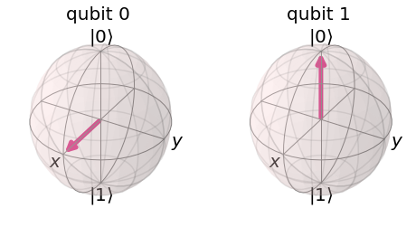

```python
backend = BasicAer.get_backend("statevector_simulator")

# Import plotting tools
from qiskit.tools.visualization import plot_bloch_multivector, plot_state_city

# Plot the Bloch sphere of the qubit state after performing the Hadamard gate
result_h = execute(qc_superposition, backend).result()
bloch_h= result_h.get_statevector(qc_superposition)
plot_bloch_multivector(bloch_h)
```

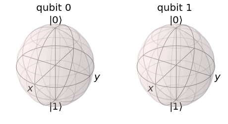

```python
# Plot the Bloch sphere of the qubit state after creating entanglement
result_bell = execute(qc_multi_qubit, backend).result()
bell= result_bell.get_statevector(qc_multi_qubit)
plot_bloch_multivector(bell)
```

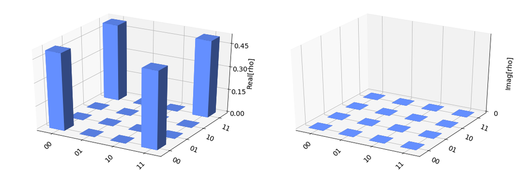

```python
plot_state_city(bell)
```

### qasm_simulator

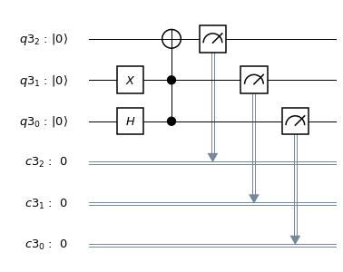

```python
qr = QuantumRegister(3)
cr = ClassicalRegister(3)
qc_toffoli = QuantumCircuit(qr,cr)
qc_toffoli.h(qr[0])
qc_toffoli.x(qr[1])
qc_toffoli.ccx(qr[0],qr[1],qr[2])
qc_toffoli.measure(qr,cr)

qc_toffoli.draw(output='mpl')
```

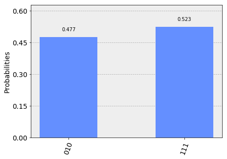

```python
backend = BasicAer.get_backend("qasm_simulator")

shots = 1024
job_bell = execute(qc_toffoli, backend, shots=shots)

from qiskit.tools.visualization import plot_histogram

result_bell = job_bell.result()
counts_bell = result_bell.get_counts(qc_toffoli)
plot_histogram(counts_bell)
```